# Covid-19 Analysis

Willem van der Schans

```
## [1] "Webpage last updated at: Thursday May 07 2020 2:10:50 PM | timezone: America/Denver"
```

```
## [1] "Last data update at 2020-05-06"
```

###### Main data source is the Johns Hopkins School of Public Health

# Visualization of Current Data

### Logarithmic Overview

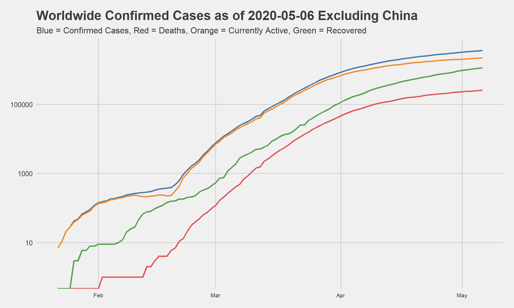

| Date | cases_confirmed | cases_recovered | cases_dead | current_active | recovery_rate | death_rate | newly_confirmed |
| --- | --- | --- | --- | --- | --- | --- | --- |
| 2020-05-06 | 3,601,708 | 1,136,707 | 254,683 | 2,210,318 | 31.56 | 7.07 | 91,001 |

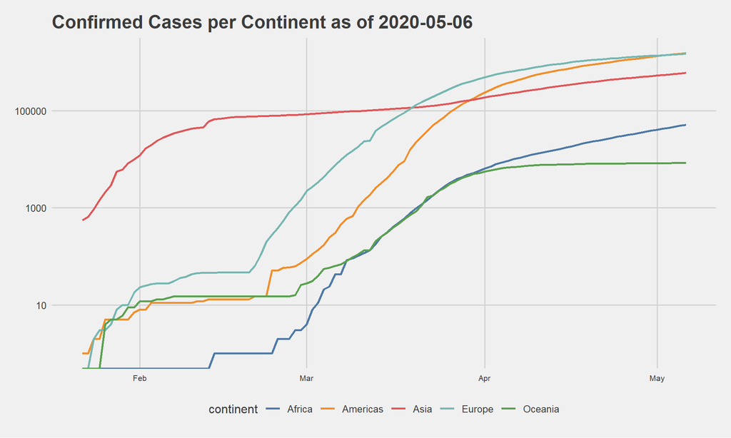

| continent | Date | Current_Confirmed | Current_Deaths | Death_Rate |
| --- | --- | --- | --- | --- |
| Americas | 2020-05-06 | 1,533,151 | 89,811 | 5.86 |
| Europe | 2020-05-06 | 1,492,032 | 146,662 | 9.83 |
| Asia | 2020-05-06 | 600,537 | 20,723 | 3.45 |
| Africa | 2020-05-06 | 51,549 | 2,006 | 3.89 |
| Oceania | 2020-05-06 | 8,409 | 118 | 1.40 |

### Confirmed Cases and Dead Cases non Logarithmic

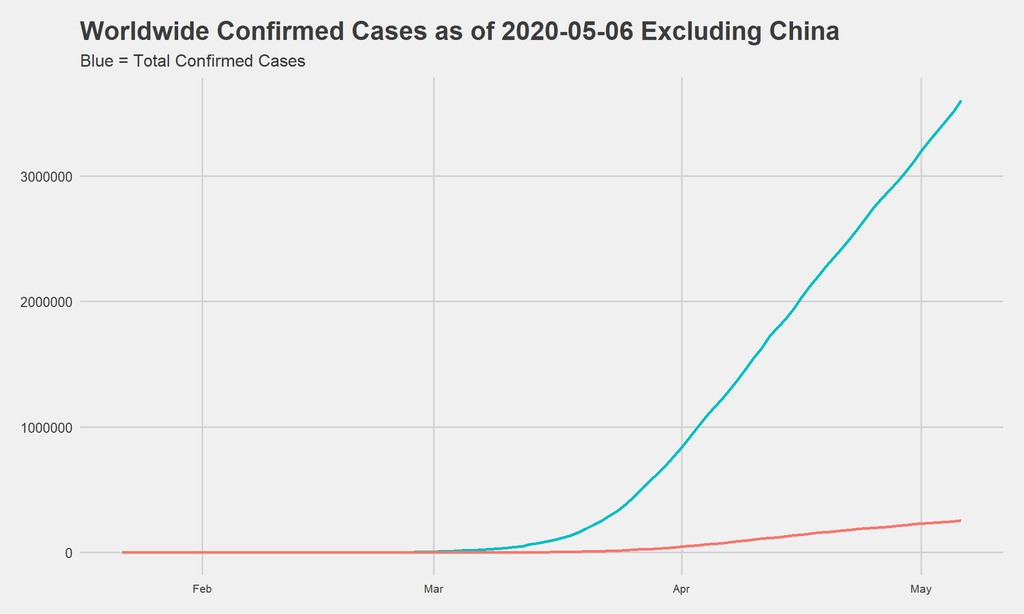

| Date | Current_Confirmed | Current_Deaths | Death_Rate |
| --- | --- | --- | --- |
| 2020-05-06 | 3,601,708 | 254,683 | 7.07 |

### Newly Confirmed Cases per Day

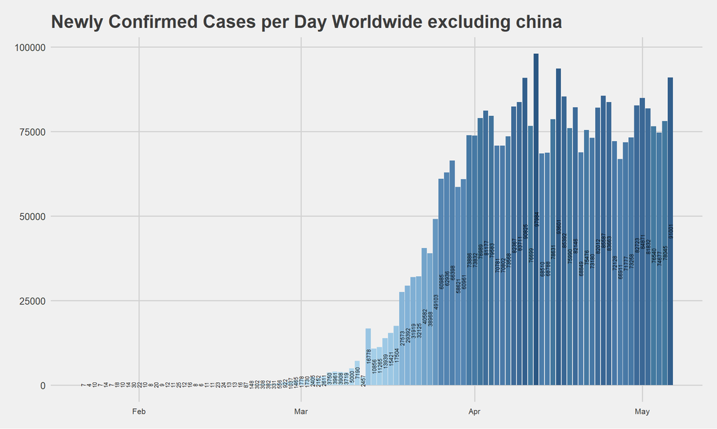

### State level newly Confirmed Cases

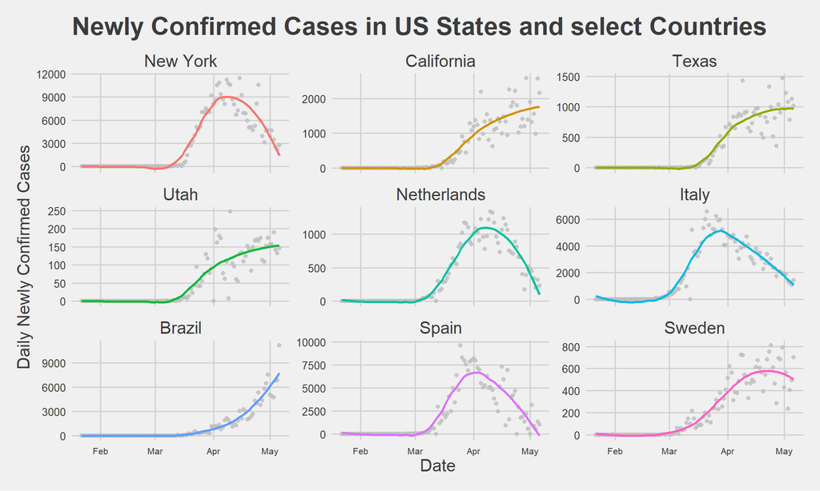

### State level newly Dead Cases

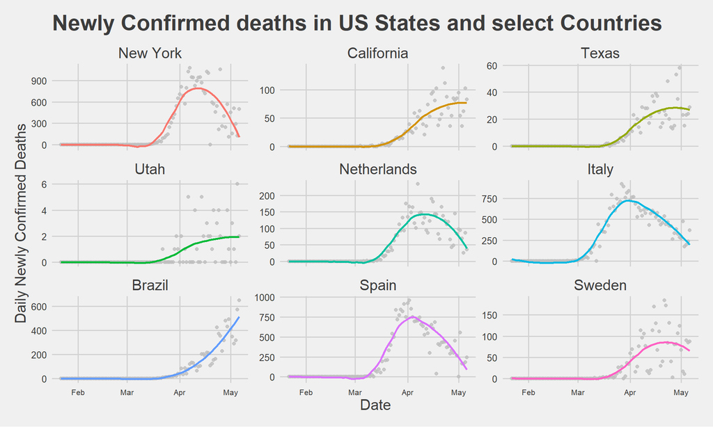

# Forecasting of Cases

Forecasting is done over a log transformed time series with ETS(AAN, not damped) with confidence levels of 95, 50, and, 25,

the data excludes China due to its deviation in time regarding the start of the COVID-19 spead compared to other countries.

### Cases Confirmed

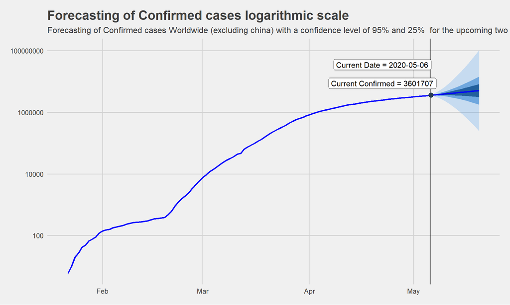

| time | Fitted | upper_25 | upper_50 | upper_95 | lower_25 | lower_50 | lower_95 |
| --- | --- | --- | --- | --- | --- | --- | --- |
| 2020-05-06 | 3,601,707 | 3,601,707 | 3,601,707 | 3,601,707 | 3,601,707 | 3,601,707 | 3,601,707 |
| 2020-05-07 | 3,688,936 | 3,764,274 | 3,850,231 | 4,177,420 | 3,615,106 | 3,534,399 | 3,257,573 |
| 2020-05-08 | 3,781,501 | 3,924,402 | 4,090,384 | 4,750,650 | 3,643,804 | 3,495,944 | 3,010,062 |
| 2020-05-09 | 3,876,389 | 4,114,349 | 4,397,404 | 5,592,136 | 3,652,192 | 3,417,105 | 2,687,057 |
| 2020-05-10 | 3,973,658 | 4,330,893 | 4,767,938 | 6,747,761 | 3,645,889 | 3,311,694 | 2,340,029 |
| 2020-05-11 | 4,073,367 | 4,574,108 | 5,206,423 | 8,311,433 | 3,627,444 | 3,186,894 | 1,996,324 |
| 2020-05-12 | 4,175,579 | 4,845,257 | 5,720,856 | 10,424,969 | 3,598,459 | 3,047,701 | 1,672,470 |
| 2020-05-13 | 4,280,355 | 5,146,265 | 6,321,911 | 13,293,490 | 3,560,143 | 2,898,085 | 1,378,226 |
| 2020-05-14 | 4,387,760 | 5,479,552 | 7,022,907 | 17,212,027 | 3,513,505 | 2,741,377 | 1,118,545 |
| 2020-05-15 | 4,497,860 | 5,847,991 | 7,840,080 | 22,606,279 | 3,459,435 | 2,580,426 | 894,917 |
| 2020-05-16 | 4,610,723 | 6,254,898 | 8,793,042 | 30,094,112 | 3,398,740 | 2,417,681 | 706,409 |
| 2020-05-17 | 4,726,418 | 6,704,060 | 9,905,392 | 40,578,459 | 3,332,164 | 2,255,239 | 550,514 |
| 2020-05-18 | 4,845,017 | 7,199,772 | 11,205,501 | 55,388,380 | 3,260,407 | 2,094,880 | 423,810 |
| 2020-05-19 | 4,966,591 | 7,746,881 | 12,727,471 | 76,494,580 | 3,184,123 | 1,938,093 | 322,467 |
| 2020-05-20 | 5,091,215 | 8,350,851 | 14,512,334 | 106,840,789 | 3,103,932 | 1,786,099 | 242,608 |

### Cases Dead

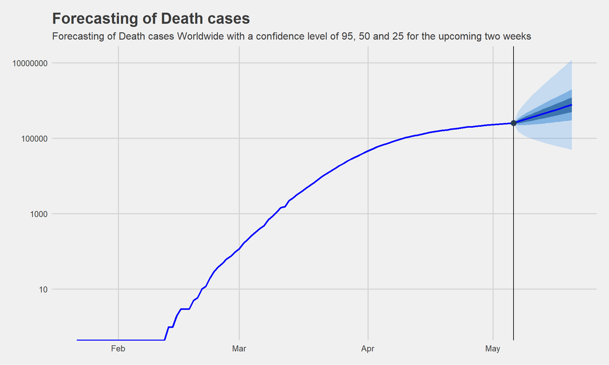

| time | Fitted | upper_25 | upper_50 | upper_95 | lower_25 | lower_50 | lower_95 |
| --- | --- | --- | --- | --- | --- | --- | --- |
| 2020-05-06 | 254,682 | 254,682 | 254,682 | 254,682 | 254,682 | 254,682 | 254,682 |
| 2020-05-07 | 276,315 | 305,249 | 341,158 | 509,847 | 250,123 | 223,796 | 149,750 |
| 2020-05-08 | 299,065 | 344,156 | 402,595 | 709,445 | 259,882 | 222,158 | 126,070 |
| 2020-05-09 | 323,689 | 385,165 | 467,720 | 943,301 | 272,025 | 224,011 | 111,072 |
| 2020-05-10 | 350,340 | 429,488 | 539,192 | 1,226,366 | 285,777 | 227,633 | 100,082 |
| 2020-05-11 | 379,185 | 477,867 | 618,720 | 1,573,104 | 300,882 | 232,385 | 91,399 |
| 2020-05-12 | 410,405 | 530,935 | 707,829 | 2,000,191 | 317,238 | 237,956 | 84,208 |
| 2020-05-13 | 444,196 | 589,313 | 808,079 | 2,527,802 | 334,814 | 244,172 | 78,055 |
| 2020-05-14 | 480,769 | 653,648 | 921,152 | 3,180,761 | 353,614 | 250,924 | 72,667 |
| 2020-05-15 | 520,354 | 724,637 | 1,048,911 | 3,989,830 | 373,660 | 258,142 | 67,864 |
| 2020-05-16 | 563,197 | 803,037 | 1,193,449 | 4,993,252 | 394,989 | 265,776 | 63,523 |
| 2020-05-17 | 609,568 | 889,679 | 1,357,131 | 6,238,679 | 417,648 | 273,793 | 59,559 |
| 2020-05-18 | 659,757 | 985,481 | 1,542,635 | 7,785,572 | 441,692 | 282,166 | 55,908 |
| 2020-05-19 | 714,078 | 1,091,456 | 1,753,012 | 9,708,212 | 467,181 | 290,875 | 52,522 |
| 2020-05-20 | 772,872 | 1,208,727 | 1,991,730 | 12,099,493 | 494,182 | 299,905 | 49,367 |

# Data Visualisation of Hospital and ICU beds

The shortage of hospital and ICU beds is visualized at the peak with a infection curve of 4 months

Once a patients is hospitalized 3-6 weeks recovery time is expected so the mean (4.5) has been taken to visualise the shortage of beads around the peak of the infection curve. The data and assumptions result in a peak on the infection curve between a Standard devition of +- 0.6462 on a Gaussian(Normal) distribution.

A severe outbreak is classified as having to hospitalize 9,600,000 cases and have 2,900,000 ICU cases in the united states, a moderate outbreak has 1,000,000 and 200,000 cases respectively. this data was obtained from the John hopkins center for health security. These number have then been converted to multipliers based on the US population and then applied to all countries available in the data set to compute both hospital and ICU cases per country for severe and moderate COVID-19 outbreaks.

The higher the number projected the worse the situation is for the country, aka less beds available for the population

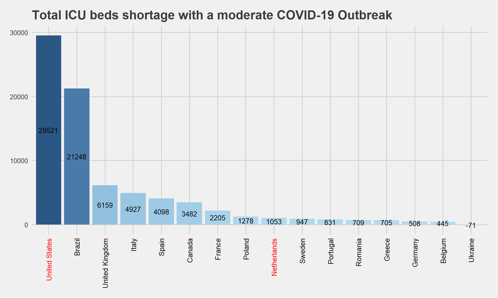

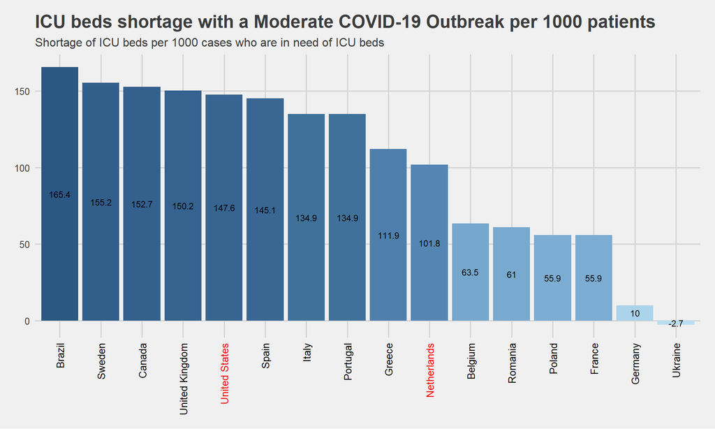

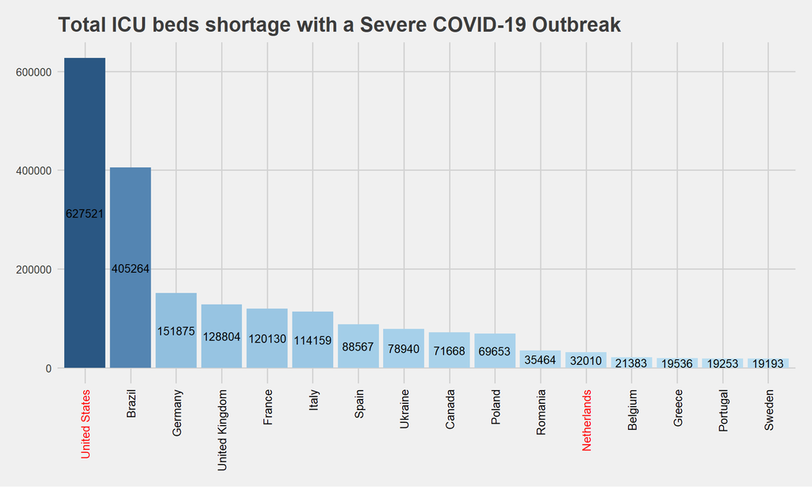

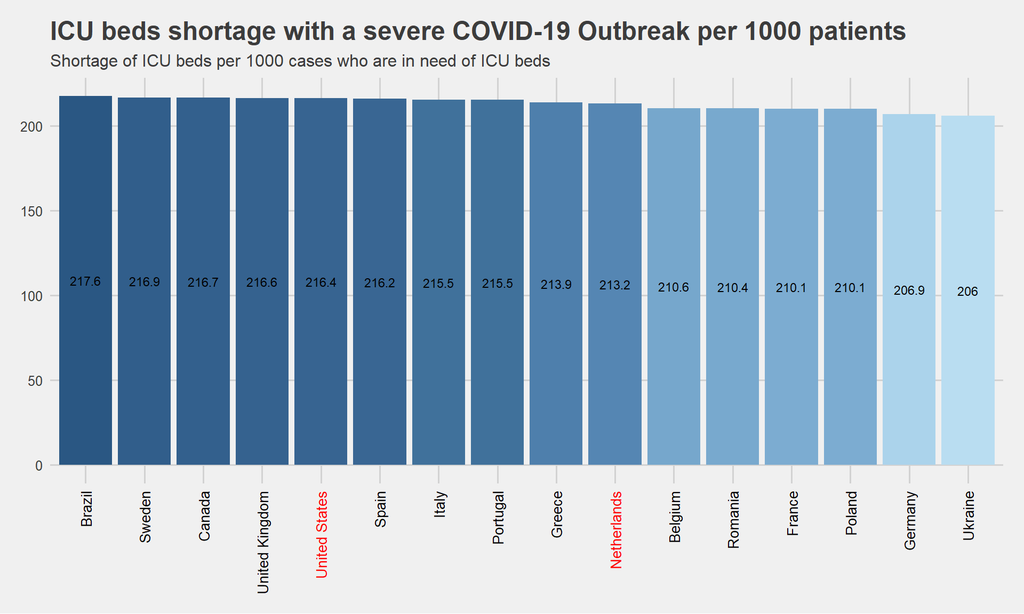

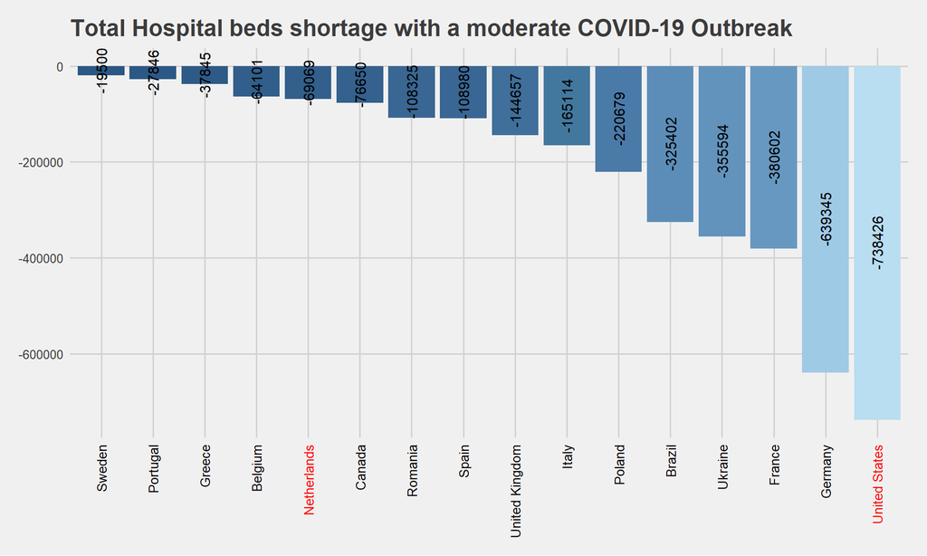

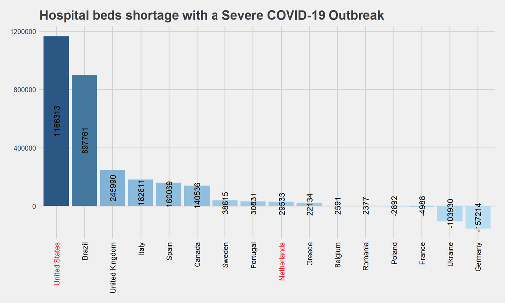

# Data Tables

### Case per Situations per Date excluding China

| Date | cases_confirmed | cases_recovered | cases_dead | current_active | recovery_rate | death_rate | newly_confirmed |
| --- | --- | --- | --- | --- | --- | --- | --- |
| 2020-01-22 | 7 | 0 | 0 | 7 | 0.00 | 0.00 | 7 |
| 2020-01-23 | 11 | 0 | 0 | 11 | 0.00 | 0.00 | 4 |
| 2020-01-24 | 21 | 0 | 0 | 21 | 0.00 | 0.00 | 10 |
| 2020-01-25 | 28 | 0 | 0 | 28 | 0.00 | 0.00 | 7 |
| 2020-01-26 | 42 | 3 | 0 | 39 | 7.14 | 0.00 | 14 |
| 2020-01-27 | 49 | 3 | 0 | 46 | 6.12 | 0.00 | 7 |
| 2020-01-28 | 67 | 6 | 0 | 61 | 8.96 | 0.00 | 18 |
| 2020-01-29 | 77 | 6 | 0 | 71 | 7.79 | 0.00 | 10 |
| 2020-01-30 | 91 | 8 | 0 | 83 | 8.79 | 0.00 | 14 |
| 2020-01-31 | 121 | 8 | 0 | 113 | 6.61 | 0.00 | 30 |
| 2020-02-01 | 143 | 9 | 0 | 134 | 6.29 | 0.00 | 22 |
| 2020-02-02 | 153 | 9 | 1 | 143 | 5.88 | 0.65 | 10 |
| 2020-02-03 | 161 | 9 | 1 | 151 | 5.59 | 0.62 | 8 |
| 2020-02-04 | 181 | 9 | 1 | 171 | 4.97 | 0.55 | 20 |
| 2020-02-05 | 190 | 9 | 1 | 180 | 4.74 | 0.53 | 9 |
| 2020-02-06 | 202 | 10 | 1 | 191 | 4.95 | 0.50 | 12 |
| 2020-02-07 | 213 | 12 | 1 | 200 | 5.63 | 0.47 | 11 |
| 2020-02-08 | 238 | 20 | 1 | 217 | 8.40 | 0.42 | 25 |
| 2020-02-09 | 250 | 25 | 1 | 224 | 10.00 | 0.40 | 12 |
| 2020-02-10 | 266 | 28 | 1 | 237 | 10.53 | 0.38 | 16 |
| 2020-02-11 | 274 | 47 | 1 | 226 | 17.15 | 0.36 | 8 |
| 2020-02-12 | 280 | 67 | 1 | 212 | 23.93 | 0.36 | 6 |
| 2020-02-13 | 291 | 77 | 2 | 212 | 26.46 | 0.69 | 11 |
| 2020-02-14 | 302 | 80 | 2 | 220 | 26.49 | 0.66 | 11 |
| 2020-02-15 | 325 | 96 | 3 | 226 | 29.54 | 0.92 | 23 |
| 2020-02-16 | 349 | 109 | 4 | 236 | 31.23 | 1.15 | 24 |
| 2020-02-17 | 362 | 120 | 4 | 238 | 33.15 | 1.10 | 13 |
| 2020-02-18 | 375 | 145 | 4 | 226 | 38.67 | 1.07 | 13 |
| 2020-02-19 | 391 | 157 | 6 | 228 | 40.15 | 1.53 | 16 |
| 2020-02-20 | 478 | 161 | 7 | 310 | 33.68 | 1.46 | 87 |

[output cut: 76 more lines]

### Death Rate and Recovery Rate per Country

| Country/Region | continent | cases_confirmed | cases_recovered | current_active | cases_dead | recovery_rate | death_rate |
| --- | --- | --- | --- | --- | --- | --- | --- |
| US | Americas | 1,228,603 | 2,854,088 | 23,304,313 | 73,431 | 10.34 | 5.26 |
| Spain | Europe | 220,325 | 2,889,047 | 3,639,151 | 25,857 | 39.67 | 10.36 |
| Italy | Europe | 214,457 | 1,913,398 | 4,557,226 | 29,684 | 25.84 | 12.62 |
| United Kingdom | Europe | 201,101 | 9,009 | 3,664,183 | 30,076 | 0.21 | 14.85 |
| France | Europe | 172,465 | 1,285,662 | 3,161,847 | 25,772 | 25.18 | 12.89 |
| Germany | Europe | 168,162 | 3,053,517 | 2,311,566 | 7,275 | 55.26 | 2.91 |
| Russia | Europe | 165,929 | 200,588 | 1,759,907 | 1,537 | 10.14 | 0.92 |
| Turkey | Asia | 131,744 | 772,215 | 2,074,627 | 3,584 | 26.46 | 2.44 |
| Brazil | Americas | 126,611 | 668,551 | 945,673 | 8,588 | 38.74 | 6.47 |
| Iran | Asia | 101,650 | 2,078,604 | 1,080,507 | 6,418 | 61.64 | 6.32 |
| China | Asia | 68,128 | 4,954,905 | 1,597,042 | 4,512 | 72.44 | 4.21 |
| Peru | Americas | 54,817 | 223,136 | 455,765 | 1,533 | 31.97 | 2.74 |
| India | Asia | 52,987 | 161,337 | 538,443 | 1,785 | 22.30 | 3.26 |
| Belgium | Europe | 50,781 | 299,951 | 897,581 | 8,339 | 21.72 | 13.28 |
| Netherlands | Europe | 41,319 | 5,784 | 1,050,129 | 5,204 | 0.49 | 11.02 |
| Saudi Arabia | Asia | 31,938 | 67,474 | 368,753 | 209 | 15.34 | 0.83 |
| Ecuador | Americas | 31,881 | 41,167 | 452,708 | 1,618 | 7.98 | 4.22 |
| Switzerland | Europe | 30,060 | 599,060 | 452,076 | 1,805 | 54.44 | 4.48 |
| Mexico | Americas | 27,634 | 180,791 | 165,865 | 2,704 | 47.60 | 8.73 |
| Portugal | Europe | 26,182 | 29,372 | 676,688 | 1,089 | 4.02 | 3.43 |
| Pakistan | Asia | 24,073 | 80,120 | 281,395 | 564 | 21.71 | 2.03 |
| Sweden | Europe | 23,918 | 30,814 | 468,394 | 2,941 | 5.54 | 10.22 |
| Chile | Americas | 23,048 | 169,019 | 227,547 | 281 | 42.10 | 1.22 |
| Ireland | Europe | 22,248 | 185,493 | 307,119 | 1,375 | 35.85 | 4.80 |
| Singapore | Asia | 20,198 | 30,784 | 275,559 | 20 | 10.04 | 0.13 |
| Belarus | Europe | 19,255 | 38,935 | 209,592 | 112 | 15.56 | 0.71 |
| Qatar | Asia | 17,972 | 25,920 | 231,820 | 12 | 10.05 | 0.11 |
| Israel | Asia | 16,310 | 159,914 | 323,347 | 239 | 32.72 | 1.12 |
| United Arab Emirates | Asia | 15,738 | 48,924 | 213,225 | 157 | 18.52 | 0.75 |
| Austria | Europe | 15,684 | 324,420 | 254,158 | 608 | 54.57 | 2.67 |

[output cut: 78 more lines]

```
## 24.11 sec elapsed
```

Future updates:

1. Visualization of infection Curve sensitivity on the max confirmed cases.
2. Table 2 add population and infections per 1000 people.
3. Find reliable and regularly updated data set with the amount of recoveries
4. fix the newly recovered cases of 12th of march
5. Extract recovered from https://datahub.io/core/covid-19/r/time-series-19-covid-combined.csv, save as csv.